# Functions

Part 3 of the RStudio Tips and Tricks Series

Jeremy Allen

Nov 2, 2021, updated on 2021-11-08

# Review

- we made a new function - clean_if_bad_names()
- shift+cmd+p for command palette
- fun/if/for/lib/ec then shift+tab to add snippets
- esquisse addin to generate plot code if new to ggplot2
- alt+dash for assignment arrow
- cmd+up in console to see history

# Functions - let’s inspect!

```r
clean_if_bad_names <- function(x) {
  if (any(str_detect(names(x), "[\\sA-Z()/-]"))) {
    x <- clean_names(x)
    x
  }
  x
}

# reset df
df <- penguins_raw

clean_if_bad_names(x = df)
```

```
## # A tibble: 344 × 17
##    study_name sample_number species        region island  stage    individual_id
##    <chr>              <dbl> <chr>          <chr>  <chr>   <chr>    <chr>
##  1 PAL0708                1 Adelie Pengui… Anvers Torger… Adult, … N1A1
##  2 PAL0708                2 Adelie Pengui… Anvers Torger… Adult, … N1A2
##  3 PAL0708                3 Adelie Pengui… Anvers Torger… Adult, … N2A1
##  4 PAL0708                4 Adelie Pengui… Anvers Torger… Adult, … N2A2
##  5 PAL0708                5 Adelie Pengui… Anvers Torger… Adult, … N3A1
##  6 PAL0708                6 Adelie Pengui… Anvers Torger… Adult, … N3A2
##  7 PAL0708                7 Adelie Pengui… Anvers Torger… Adult, … N4A1
##  8 PAL0708                8 Adelie Pengui… Anvers Torger… Adult, … N4A2
##  9 PAL0708                9 Adelie Pengui… Anvers Torger… Adult, … N5A1
## 10 PAL0708               10 Adelie Pengui… Anvers Torger… Adult, … N5A2
## # … with 334 more rows, and 10 more variables: clutch_completion <chr>,
## #   date_egg <date>, culmen_length_mm <dbl>, culmen_depth_mm <dbl>,
## #   flipper_length_mm <dbl>, body_mass_g <dbl>, sex <chr>,
## #   delta_15_n_o_oo <dbl>, delta_13_c_o_oo <dbl>, comments <chr>
```

# But we don’t really need that silly function

clean_names() from the janitor package looks for more bad elements in names  
How do we know?  
😄 Pro tip: cmd+click or F2 on a function name to inspect it’s body

```r
janitor::clean_names()
```

```r
# we don't really need to test first, just clean the column names
df <- penguins_raw %>% janitor::clean_names()
```

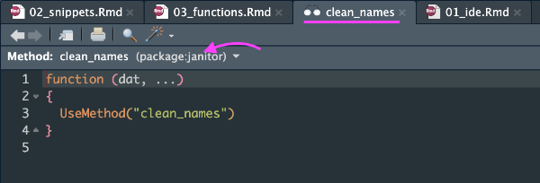

Select the data.frame method from the drop down

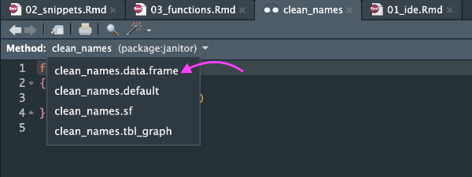

Then cmd click the internal function make_clean_names()

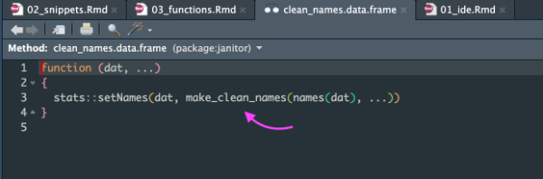

Now we see the internals of janitor’s make_clean_names(), we see it cleans up apostrophes and other things our function didn’t test for.

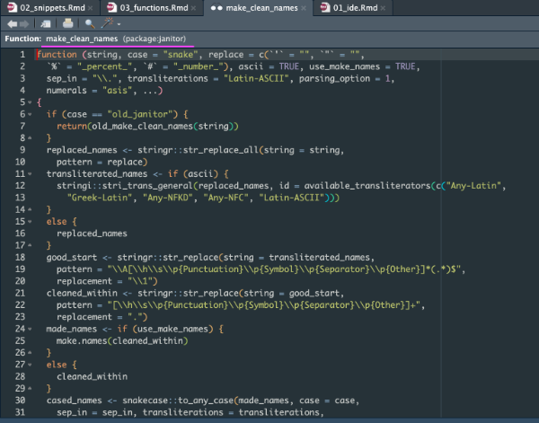

# What other functions do you want to inspect?

```r
dplyr::arrange()
```

## Water cooler chat: Chunk options in gear icon

In the chunk above, the options in the gear icon do not provide a way for:  
`{r echo=TRUE, eval=FALSE}`  
which means to show the code but do not run the code.

## Function and snippet mashup

😄 combine some functions into one function using purrr::compose()

```r
not_in <- purrr::compose( # by default it runs bottom to top
  `!`,
  `%in%`
)
```

```r
not_in(3, c(1:2))
```

```
## [1] TRUE
```

```r
not_in(1, c(1:2))
```

```
## [1] FALSE
```

```r
not_in("January", month.name)
```

```
## [1] FALSE
```

```r
library(broom)
library(gt)

lm_peek <- purrr::compose(
  .dir = "forward",
  lm,
  broom::tidy,
  gt::gt,
  ~tab_header(.x, title = "Results Preview")
)

# this
lm_peek(culmen_depth_mm ~ flipper_length_mm + body_mass_g, data = df)
```

Results Preview

| term | estimate | std.error | statistic | p.value |
| --- | --- | --- | --- | --- |
| (Intercept) | 35.7949967216 | 1.7785312629 | 20.126155 | 7.917591e-60 |
| flipper_length_mm | -0.1006442960 | 0.0125602140 | -8.012944 | 1.823056e-14 |
| body_mass_g | 0.0003753533 | 0.0002202346 | 1.704334 | 8.923502e-02 |

## Got code?

😄 Pro tip: highlight code, then in Code menu, select extract function

```r
# in the code menu, select extract function

df %>%
    filter(Sex == "MALE") %>%
    summarise(mean_body_mass = mean(`Body Mass (g)`, na.rm = TRUE))
```